# Risk Factor Analysis

## Outcome Variable

**Outcome Variable:** swasted

## Predictor Variables

**Intervention Variable:** birthlen

**Adjustment Set:**

- arm
- sex
- W_mage
- meducyrs
- feducyrs
- vagbrth
- single
- brthmon
- W_parity
- delta_W_mage
- delta_meducyrs
- delta_feducyrs
- delta_vagbrth
- delta_single
- delta_brthmon
- delta_W_parity

## Stratifying Variables

The analysis was stratified on these variable(s):

- agecat
- studyid
- country

## Data Summary

| agecat | studyid | country | birthlen | swasted | n_cell | n |
| --- | --- | --- | --- | --- | --- | --- |
| Birth | CMC-V-BCS-2002 | INDIA | >=50 cm | 0 | 13 | 86 |
| Birth | CMC-V-BCS-2002 | INDIA | >=50 cm | 1 | 0 | 86 |
| Birth | CMC-V-BCS-2002 | INDIA | <48 cm | 0 | 32 | 86 |
| Birth | CMC-V-BCS-2002 | INDIA | <48 cm | 1 | 1 | 86 |
| Birth | CMC-V-BCS-2002 | INDIA | [48-50) cm | 0 | 40 | 86 |
| Birth | CMC-V-BCS-2002 | INDIA | [48-50) cm | 1 | 0 | 86 |
| Birth | CMIN | BANGLADESH | >=50 cm | 0 | 2 | 19 |
| Birth | CMIN | BANGLADESH | >=50 cm | 1 | 0 | 19 |
| Birth | CMIN | BANGLADESH | <48 cm | 0 | 8 | 19 |
| Birth | CMIN | BANGLADESH | <48 cm | 1 | 1 | 19 |
| Birth | CMIN | BANGLADESH | [48-50) cm | 0 | 8 | 19 |
| Birth | CMIN | BANGLADESH | [48-50) cm | 1 | 0 | 19 |
| Birth | COHORTS | GUATEMALA | >=50 cm | 0 | 351 | 756 |
| Birth | COHORTS | GUATEMALA | >=50 cm | 1 | 45 | 756 |
| Birth | COHORTS | GUATEMALA | <48 cm | 0 | 129 | 756 |
| Birth | COHORTS | GUATEMALA | <48 cm | 1 | 3 | 756 |
| Birth | COHORTS | GUATEMALA | [48-50) cm | 0 | 216 | 756 |
| Birth | COHORTS | GUATEMALA | [48-50) cm | 1 | 12 | 756 |
| Birth | COHORTS | INDIA | >=50 cm | 0 | 1310 | 6193 |
| Birth | COHORTS | INDIA | >=50 cm | 1 | 94 | 6193 |
| Birth | COHORTS | INDIA | <48 cm | 0 | 2258 | 6193 |
| Birth | COHORTS | INDIA | <48 cm | 1 | 96 | 6193 |
| Birth | COHORTS | INDIA | [48-50) cm | 0 | 2305 | 6193 |
| Birth | COHORTS | INDIA | [48-50) cm | 1 | 130 | 6193 |
| Birth | COHORTS | PHILIPPINES | >=50 cm | 0 | 1042 | 2899 |
| Birth | COHORTS | PHILIPPINES | >=50 cm | 1 | 68 | 2899 |
| Birth | COHORTS | PHILIPPINES | <48 cm | 0 | 626 | 2899 |
| Birth | COHORTS | PHILIPPINES | <48 cm | 1 | 25 | 2899 |
| Birth | COHORTS | PHILIPPINES | [48-50) cm | 0 | 1110 | 2899 |
| Birth | COHORTS | PHILIPPINES | [48-50) cm | 1 | 28 | 2899 |

[output cut: 426 more lines]

The following strata were considered:

- agecat: 24 months, studyid: CMC-V-BCS-2002, country: INDIA
- agecat: 24 months, studyid: CMIN, country: BANGLADESH
- agecat: 24 months, studyid: COHORTS, country: GUATEMALA
- agecat: 24 months, studyid: COHORTS, country: INDIA
- agecat: 24 months, studyid: COHORTS, country: PHILIPPINES
- agecat: 24 months, studyid: CONTENT, country: PERU
- agecat: 24 months, studyid: EE, country: PAKISTAN
- agecat: 24 months, studyid: GMS-Nepal, country: NEPAL
- agecat: 24 months, studyid: IRC, country: INDIA
- agecat: 24 months, studyid: JiVitA-3, country: BANGLADESH
- agecat: 24 months, studyid: JiVitA-4, country: BANGLADESH
- agecat: 24 months, studyid: Keneba, country: GAMBIA
- agecat: 24 months, studyid: MAL-ED, country: BANGLADESH
- agecat: 24 months, studyid: MAL-ED, country: BRAZIL
- agecat: 24 months, studyid: MAL-ED, country: INDIA
- agecat: 24 months, studyid: MAL-ED, country: NEPAL
- agecat: 24 months, studyid: MAL-ED, country: PERU
- agecat: 24 months, studyid: MAL-ED, country: SOUTH AFRICA
- agecat: 24 months, studyid: MAL-ED, country: TANZANIA, UNITED REPUBLIC OF
- agecat: 24 months, studyid: NIH-Birth, country: BANGLADESH
- agecat: 24 months, studyid: NIH-Crypto, country: BANGLADESH
- agecat: 24 months, studyid: PROBIT, country: BELARUS
- agecat: 24 months, studyid: PROVIDE, country: BANGLADESH
- agecat: 24 months, studyid: ZVITAMBO, country: ZIMBABWE
- agecat: 6 months, studyid: CMC-V-BCS-2002, country: INDIA
- agecat: 6 months, studyid: CMIN, country: BANGLADESH
- agecat: 6 months, studyid: COHORTS, country: GUATEMALA
- agecat: 6 months, studyid: COHORTS, country: INDIA
- agecat: 6 months, studyid: COHORTS, country: PHILIPPINES
- agecat: 6 months, studyid: CONTENT, country: PERU
- agecat: 6 months, studyid: EE, country: PAKISTAN
- agecat: 6 months, studyid: GMS-Nepal, country: NEPAL
- agecat: 6 months, studyid: IRC, country: INDIA
- agecat: 6 months, studyid: JiVitA-3, country: BANGLADESH
- agecat: 6 months, studyid: JiVitA-4, country: BANGLADESH
- agecat: 6 months, studyid: Keneba, country: GAMBIA
- agecat: 6 months, studyid: MAL-ED, country: BANGLADESH
- agecat: 6 months, studyid: MAL-ED, country: BRAZIL
- agecat: 6 months, studyid: MAL-ED, country: INDIA
- agecat: 6 months, studyid: MAL-ED, country: NEPAL
- agecat: 6 months, studyid: MAL-ED, country: PERU
- agecat: 6 months, studyid: MAL-ED, country: SOUTH AFRICA
- agecat: 6 months, studyid: MAL-ED, country: TANZANIA, UNITED REPUBLIC OF
- agecat: 6 months, studyid: NIH-Birth, country: BANGLADESH
- agecat: 6 months, studyid: NIH-Crypto, country: BANGLADESH
- agecat: 6 months, studyid: PROBIT, country: BELARUS
- agecat: 6 months, studyid: PROVIDE, country: BANGLADESH
- agecat: 6 months, studyid: ResPak, country: PAKISTAN
- agecat: 6 months, studyid: SAS-CompFeed, country: INDIA
- agecat: 6 months, studyid: ZVITAMBO, country: ZIMBABWE
- agecat: Birth, studyid: CMC-V-BCS-2002, country: INDIA
- agecat: Birth, studyid: CMIN, country: BANGLADESH
- agecat: Birth, studyid: COHORTS, country: GUATEMALA
- agecat: Birth, studyid: COHORTS, country: INDIA
- agecat: Birth, studyid: COHORTS, country: PHILIPPINES
- agecat: Birth, studyid: CONTENT, country: PERU
- agecat: Birth, studyid: EE, country: PAKISTAN
- agecat: Birth, studyid: GMS-Nepal, country: NEPAL
- agecat: Birth, studyid: IRC, country: INDIA
- agecat: Birth, studyid: JiVitA-3, country: BANGLADESH
- agecat: Birth, studyid: JiVitA-4, country: BANGLADESH
- agecat: Birth, studyid: Keneba, country: GAMBIA
- agecat: Birth, studyid: MAL-ED, country: BANGLADESH
- agecat: Birth, studyid: MAL-ED, country: BRAZIL
- agecat: Birth, studyid: MAL-ED, country: INDIA
- agecat: Birth, studyid: MAL-ED, country: NEPAL
- agecat: Birth, studyid: MAL-ED, country: PERU
- agecat: Birth, studyid: MAL-ED, country: SOUTH AFRICA
- agecat: Birth, studyid: MAL-ED, country: TANZANIA, UNITED REPUBLIC OF
- agecat: Birth, studyid: NIH-Birth, country: BANGLADESH
- agecat: Birth, studyid: NIH-Crypto, country: BANGLADESH
- agecat: Birth, studyid: PROBIT, country: BELARUS
- agecat: Birth, studyid: PROVIDE, country: BANGLADESH
- agecat: Birth, studyid: ResPak, country: PAKISTAN
- agecat: Birth, studyid: SAS-CompFeed, country: INDIA
- agecat: Birth, studyid: ZVITAMBO, country: ZIMBABWE

### Dropped Strata

Some strata were dropped due to rare outcomes:

- agecat: Birth, studyid: CMC-V-BCS-2002, country: INDIA
- agecat: Birth, studyid: CMIN, country: BANGLADESH
- agecat: Birth, studyid: COHORTS, country: GUATEMALA
- agecat: Birth, studyid: CONTENT, country: PERU
- agecat: Birth, studyid: EE, country: PAKISTAN
- agecat: Birth, studyid: JiVitA-4, country: BANGLADESH
- agecat: Birth, studyid: MAL-ED, country: BANGLADESH
- agecat: Birth, studyid: MAL-ED, country: BRAZIL
- agecat: Birth, studyid: MAL-ED, country: INDIA
- agecat: Birth, studyid: MAL-ED, country: NEPAL
- agecat: Birth, studyid: MAL-ED, country: PERU
- agecat: Birth, studyid: MAL-ED, country: SOUTH AFRICA
- agecat: Birth, studyid: MAL-ED, country: TANZANIA, UNITED REPUBLIC OF
- agecat: Birth, studyid: PROBIT, country: BELARUS
- agecat: Birth, studyid: PROVIDE, country: BANGLADESH
- agecat: Birth, studyid: ResPak, country: PAKISTAN
- agecat: Birth, studyid: SAS-CompFeed, country: INDIA
- agecat: 6 months, studyid: CMC-V-BCS-2002, country: INDIA
- agecat: 6 months, studyid: CMIN, country: BANGLADESH
- agecat: 6 months, studyid: COHORTS, country: GUATEMALA
- agecat: 6 months, studyid: CONTENT, country: PERU
- agecat: 6 months, studyid: EE, country: PAKISTAN
- agecat: 6 months, studyid: GMS-Nepal, country: NEPAL
- agecat: 6 months, studyid: IRC, country: INDIA
- agecat: 6 months, studyid: JiVitA-4, country: BANGLADESH
- agecat: 6 months, studyid: Keneba, country: GAMBIA
- agecat: 6 months, studyid: MAL-ED, country: BANGLADESH
- agecat: 6 months, studyid: MAL-ED, country: BRAZIL
- agecat: 6 months, studyid: MAL-ED, country: INDIA
- agecat: 6 months, studyid: MAL-ED, country: NEPAL
- agecat: 6 months, studyid: MAL-ED, country: PERU
- agecat: 6 months, studyid: MAL-ED, country: SOUTH AFRICA
- agecat: 6 months, studyid: MAL-ED, country: TANZANIA, UNITED REPUBLIC OF
- agecat: 6 months, studyid: NIH-Birth, country: BANGLADESH
- agecat: 6 months, studyid: NIH-Crypto, country: BANGLADESH
- agecat: 6 months, studyid: PROBIT, country: BELARUS
- agecat: 6 months, studyid: PROVIDE, country: BANGLADESH
- agecat: 6 months, studyid: ResPak, country: PAKISTAN
- agecat: 6 months, studyid: SAS-CompFeed, country: INDIA
- agecat: 24 months, studyid: CMC-V-BCS-2002, country: INDIA
- agecat: 24 months, studyid: CMIN, country: BANGLADESH
- agecat: 24 months, studyid: COHORTS, country: GUATEMALA
- agecat: 24 months, studyid: COHORTS, country: PHILIPPINES
- agecat: 24 months, studyid: CONTENT, country: PERU
- agecat: 24 months, studyid: EE, country: PAKISTAN
- agecat: 24 months, studyid: GMS-Nepal, country: NEPAL
- agecat: 24 months, studyid: IRC, country: INDIA
- agecat: 24 months, studyid: MAL-ED, country: BANGLADESH
- agecat: 24 months, studyid: MAL-ED, country: BRAZIL
- agecat: 24 months, studyid: MAL-ED, country: INDIA
- agecat: 24 months, studyid: MAL-ED, country: NEPAL
- agecat: 24 months, studyid: MAL-ED, country: PERU
- agecat: 24 months, studyid: MAL-ED, country: SOUTH AFRICA
- agecat: 24 months, studyid: MAL-ED, country: TANZANIA, UNITED REPUBLIC OF
- agecat: 24 months, studyid: NIH-Birth, country: BANGLADESH
- agecat: 24 months, studyid: NIH-Crypto, country: BANGLADESH
- agecat: 24 months, studyid: PROBIT, country: BELARUS
- agecat: 24 months, studyid: PROVIDE, country: BANGLADESH
- agecat: 24 months, studyid: ZVITAMBO, country: ZIMBABWE

## Methods Detail

We’re interested in the causal parameters $E[Y_a]$ for all values of $a \in \mathcal{A}$. These parameters represent the mean outcome if, possibly contrary to fact, we intervened to set all units to have $A=a$. Under the randomization and positivity assumptions, these are identified by the statistical parameters $\psi_a=E_W[E_{Y|A,W}(Y|A=a,W)]$. In addition, we’re interested in the mean of $Y$, $E[Y]$ under no intervention (the observed mean). We will estimate these parameters by using SuperLearner to fit the relevant likelihood factors – $E_{Y|A,W}(Y|A=a,W)$ and $p(A=a|W)$, and then updating our likelihood fit using a joint TMLE.

For unadjusted analyses ($W=\{\}$), initial likelihoods were estimated using Lrnr_glm to estimate the simple $E(Y|A)$ and Lrnr_mean to estimate $p(A)$. For adjusted analyses, a small library containing Lrnr_glmnet, Lrnr_xgboost, and Lrnr_mean was used.

Having estimated these parameters, we will then use the delta method to estimate relative risks and attributable risks relative to a prespecified baseline level of $A$.

# Results Detail

## Results Plots

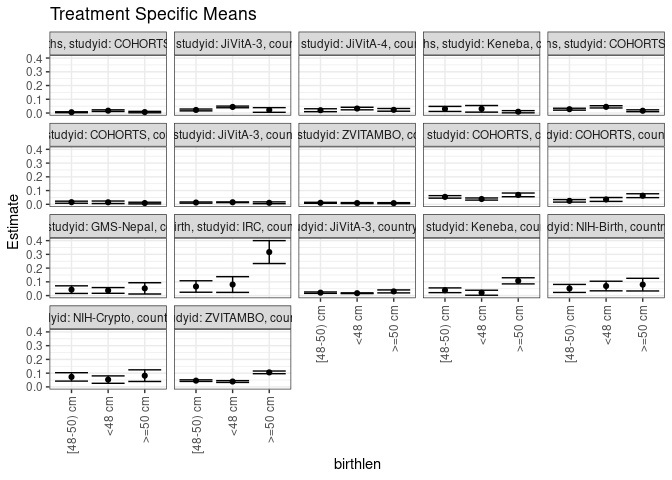

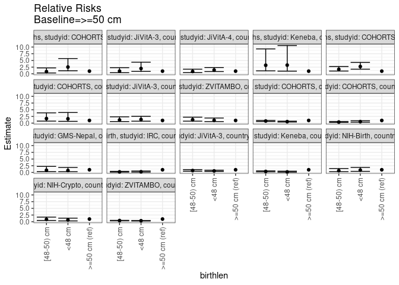

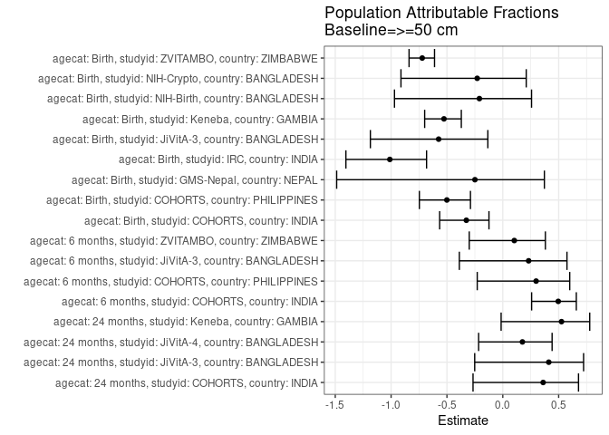

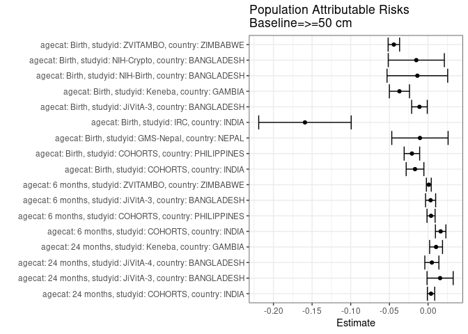

## Results Table

### Parameter: TSM

| agecat | studyid | country | intervention_level | baseline_level | estimate | ci_lower | ci_upper |
| --- | --- | --- | --- | --- | --- | --- | --- |
| Birth | COHORTS | INDIA | >=50 cm | NA | 0.0685322 | 0.0551762 | 0.0818883 |
| Birth | COHORTS | INDIA | <48 cm | NA | 0.0385103 | 0.0307795 | 0.0462411 |
| Birth | COHORTS | INDIA | [48-50) cm | NA | 0.0540998 | 0.0449897 | 0.0632100 |
| Birth | COHORTS | PHILIPPINES | >=50 cm | NA | 0.0626440 | 0.0484860 | 0.0768019 |
| Birth | COHORTS | PHILIPPINES | <48 cm | NA | 0.0352318 | 0.0210920 | 0.0493715 |
| Birth | COHORTS | PHILIPPINES | [48-50) cm | NA | 0.0251759 | 0.0160853 | 0.0342665 |
| Birth | GMS-Nepal | NEPAL | >=50 cm | NA | 0.0526316 | 0.0116095 | 0.0936536 |
| Birth | GMS-Nepal | NEPAL | <48 cm | NA | 0.0376176 | 0.0167217 | 0.0585134 |
| Birth | GMS-Nepal | NEPAL | [48-50) cm | NA | 0.0432692 | 0.0155973 | 0.0709412 |
| Birth | IRC | INDIA | >=50 cm | NA | 0.3166667 | 0.2333160 | 0.4000173 |
| Birth | IRC | INDIA | <48 cm | NA | 0.0804598 | 0.0232201 | 0.1376995 |
| Birth | IRC | INDIA | [48-50) cm | NA | 0.0661765 | 0.0243360 | 0.1080170 |
| Birth | JiVitA-3 | BANGLADESH | >=50 cm | NA | 0.0304990 | 0.0198002 | 0.0411978 |
| Birth | JiVitA-3 | BANGLADESH | <48 cm | NA | 0.0173828 | 0.0148127 | 0.0199528 |
| Birth | JiVitA-3 | BANGLADESH | [48-50) cm | NA | 0.0213367 | 0.0162704 | 0.0264030 |
| Birth | Keneba | GAMBIA | >=50 cm | NA | 0.1073370 | 0.0849664 | 0.1297075 |
| Birth | Keneba | GAMBIA | <48 cm | NA | 0.0208333 | 0.0027575 | 0.0389092 |
| Birth | Keneba | GAMBIA | [48-50) cm | NA | 0.0388548 | 0.0217208 | 0.0559888 |
| Birth | NIH-Birth | BANGLADESH | >=50 cm | NA | 0.0799279 | 0.0338655 | 0.1259904 |
| Birth | NIH-Birth | BANGLADESH | <48 cm | NA | 0.0696600 | 0.0347900 | 0.1045301 |
| Birth | NIH-Birth | BANGLADESH | [48-50) cm | NA | 0.0521624 | 0.0229424 | 0.0813825 |
| Birth | NIH-Crypto | BANGLADESH | >=50 cm | NA | 0.0817025 | 0.0393842 | 0.1240209 |
| Birth | NIH-Crypto | BANGLADESH | <48 cm | NA | 0.0529087 | 0.0260180 | 0.0797993 |
| Birth | NIH-Crypto | BANGLADESH | [48-50) cm | NA | 0.0726579 | 0.0421891 | 0.1031266 |
| Birth | ZVITAMBO | ZIMBABWE | >=50 cm | NA | 0.1055505 | 0.0958980 | 0.1152030 |
| Birth | ZVITAMBO | ZIMBABWE | <48 cm | NA | 0.0390045 | 0.0326061 | 0.0454029 |
| Birth | ZVITAMBO | ZIMBABWE | [48-50) cm | NA | 0.0454723 | 0.0397384 | 0.0512062 |
| 6 months | COHORTS | INDIA | >=50 cm | NA | 0.0165198 | 0.0097385 | 0.0233011 |
| 6 months | COHORTS | INDIA | <48 cm | NA | 0.0449441 | 0.0368691 | 0.0530191 |
| 6 months | COHORTS | INDIA | [48-50) cm | NA | 0.0278646 | 0.0209937 | 0.0347355 |
| 6 months | COHORTS | PHILIPPINES | >=50 cm | NA | 0.0091001 | 0.0031808 | 0.0150194 |
| 6 months | COHORTS | PHILIPPINES | <48 cm | NA | 0.0147710 | 0.0056822 | 0.0238599 |
| 6 months | COHORTS | PHILIPPINES | [48-50) cm | NA | 0.0154889 | 0.0079571 | 0.0230207 |
| 6 months | JiVitA-3 | BANGLADESH | >=50 cm | NA | 0.0108959 | 0.0044253 | 0.0173665 |
| 6 months | JiVitA-3 | BANGLADESH | <48 cm | NA | 0.0148888 | 0.0120858 | 0.0176919 |
| 6 months | JiVitA-3 | BANGLADESH | [48-50) cm | NA | 0.0128558 | 0.0085196 | 0.0171921 |
| 6 months | ZVITAMBO | ZIMBABWE | >=50 cm | NA | 0.0084234 | 0.0047801 | 0.0120668 |
| 6 months | ZVITAMBO | ZIMBABWE | <48 cm | NA | 0.0088753 | 0.0052667 | 0.0124840 |
| 6 months | ZVITAMBO | ZIMBABWE | [48-50) cm | NA | 0.0108306 | 0.0072332 | 0.0144280 |
| 24 months | COHORTS | INDIA | >=50 cm | NA | 0.0067633 | 0.0017695 | 0.0117571 |
| 24 months | COHORTS | INDIA | <48 cm | NA | 0.0171162 | 0.0113260 | 0.0229064 |
| 24 months | COHORTS | INDIA | [48-50) cm | NA | 0.0056850 | 0.0021711 | 0.0091990 |
| 24 months | JiVitA-3 | BANGLADESH | >=50 cm | NA | 0.0222772 | 0.0052361 | 0.0393183 |
| 24 months | JiVitA-3 | BANGLADESH | <48 cm | NA | 0.0443564 | 0.0382215 | 0.0504914 |
| 24 months | JiVitA-3 | BANGLADESH | [48-50) cm | NA | 0.0222874 | 0.0156040 | 0.0289708 |
| 24 months | JiVitA-4 | BANGLADESH | >=50 cm | NA | 0.0230258 | 0.0131678 | 0.0328838 |
| 24 months | JiVitA-4 | BANGLADESH | <48 cm | NA | 0.0325722 | 0.0232610 | 0.0418834 |
| 24 months | JiVitA-4 | BANGLADESH | [48-50) cm | NA | 0.0204224 | 0.0098733 | 0.0309716 |
| 24 months | Keneba | GAMBIA | >=50 cm | NA | 0.0093458 | 0.0011885 | 0.0175031 |
| 24 months | Keneba | GAMBIA | <48 cm | NA | 0.0304569 | 0.0064495 | 0.0544642 |
| 24 months | Keneba | GAMBIA | [48-50) cm | NA | 0.0299401 | 0.0116547 | 0.0482255 |

### Parameter: E(Y)

| agecat | studyid | country | intervention_level | baseline_level | estimate | ci_lower | ci_upper |
| --- | --- | --- | --- | --- | --- | --- | --- |
| Birth | COHORTS | INDIA | NA | NA | 0.0516712 | 0.0461576 | 0.0571849 |
| Birth | COHORTS | PHILIPPINES | NA | NA | 0.0417385 | 0.0344572 | 0.0490198 |
| Birth | GMS-Nepal | NEPAL | NA | NA | 0.0421217 | 0.0265597 | 0.0576837 |
| Birth | IRC | INDIA | NA | NA | 0.1574344 | 0.1188345 | 0.1960344 |
| Birth | JiVitA-3 | BANGLADESH | NA | NA | 0.0193738 | 0.0169653 | 0.0217823 |
| Birth | Keneba | GAMBIA | NA | NA | 0.0703072 | 0.0572109 | 0.0834034 |
| Birth | NIH-Birth | BANGLADESH | NA | NA | 0.0660870 | 0.0457632 | 0.0864107 |
| Birth | NIH-Crypto | BANGLADESH | NA | NA | 0.0664781 | 0.0481022 | 0.0848539 |
| Birth | ZVITAMBO | ZIMBABWE | NA | NA | 0.0613145 | 0.0571772 | 0.0654519 |
| 6 months | COHORTS | INDIA | NA | NA | 0.0328056 | 0.0283450 | 0.0372662 |
| 6 months | COHORTS | PHILIPPINES | NA | NA | 0.0129678 | 0.0086988 | 0.0172368 |
| 6 months | JiVitA-3 | BANGLADESH | NA | NA | 0.0141737 | 0.0119136 | 0.0164337 |
| 6 months | ZVITAMBO | ZIMBABWE | NA | NA | 0.0093902 | 0.0073292 | 0.0114513 |
| 24 months | COHORTS | INDIA | NA | NA | 0.0105887 | 0.0076690 | 0.0135085 |
| 24 months | JiVitA-3 | BANGLADESH | NA | NA | 0.0378544 | 0.0331920 | 0.0425169 |
| 24 months | JiVitA-4 | BANGLADESH | NA | NA | 0.0279316 | 0.0220494 | 0.0338137 |
| 24 months | Keneba | GAMBIA | NA | NA | 0.0196998 | 0.0113537 | 0.0280459 |

### Parameter: RR

| agecat | studyid | country | intervention_level | baseline_level | estimate | ci_lower | ci_upper |
| --- | --- | --- | --- | --- | --- | --- | --- |
| Birth | COHORTS | INDIA | >=50 cm | >=50 cm | 1.0000000 | 1.0000000 | 1.0000000 |
| Birth | COHORTS | INDIA | <48 cm | >=50 cm | 0.5619295 | 0.4248562 | 0.7432274 |
| Birth | COHORTS | INDIA | [48-50) cm | >=50 cm | 0.7894071 | 0.6101941 | 1.0212546 |
| Birth | COHORTS | PHILIPPINES | >=50 cm | >=50 cm | 1.0000000 | 1.0000000 | 1.0000000 |
| Birth | COHORTS | PHILIPPINES | <48 cm | >=50 cm | 0.5624129 | 0.3549470 | 0.8911423 |
| Birth | COHORTS | PHILIPPINES | [48-50) cm | >=50 cm | 0.4018888 | 0.2625644 | 0.6151427 |
| Birth | GMS-Nepal | NEPAL | >=50 cm | >=50 cm | 1.0000000 | 1.0000000 | 1.0000000 |
| Birth | GMS-Nepal | NEPAL | <48 cm | >=50 cm | 0.7147335 | 0.2744591 | 1.8612754 |
| Birth | GMS-Nepal | NEPAL | [48-50) cm | >=50 cm | 0.8221154 | 0.2999658 | 2.2531693 |
| Birth | IRC | INDIA | >=50 cm | >=50 cm | 1.0000000 | 1.0000000 | 1.0000000 |
| Birth | IRC | INDIA | <48 cm | >=50 cm | 0.2540835 | 0.1190000 | 0.5425075 |
| Birth | IRC | INDIA | [48-50) cm | >=50 cm | 0.2089783 | 0.1053590 | 0.4145060 |
| Birth | JiVitA-3 | BANGLADESH | >=50 cm | >=50 cm | 1.0000000 | 1.0000000 | 1.0000000 |
| Birth | JiVitA-3 | BANGLADESH | <48 cm | >=50 cm | 0.5699464 | 0.3907261 | 0.8313724 |
| Birth | JiVitA-3 | BANGLADESH | [48-50) cm | >=50 cm | 0.6995862 | 0.4614145 | 1.0606966 |
| Birth | Keneba | GAMBIA | >=50 cm | >=50 cm | 1.0000000 | 1.0000000 | 1.0000000 |
| Birth | Keneba | GAMBIA | <48 cm | >=50 cm | 0.1940928 | 0.0795206 | 0.4737392 |
| Birth | Keneba | GAMBIA | [48-50) cm | >=50 cm | 0.3619891 | 0.2222647 | 0.5895498 |
| Birth | NIH-Birth | BANGLADESH | >=50 cm | >=50 cm | 1.0000000 | 1.0000000 | 1.0000000 |
| Birth | NIH-Birth | BANGLADESH | <48 cm | >=50 cm | 0.8715353 | 0.4063241 | 1.8693791 |
| Birth | NIH-Birth | BANGLADESH | [48-50) cm | >=50 cm | 0.6526185 | 0.2919707 | 1.4587453 |
| Birth | NIH-Crypto | BANGLADESH | >=50 cm | >=50 cm | 1.0000000 | 1.0000000 | 1.0000000 |
| Birth | NIH-Crypto | BANGLADESH | <48 cm | >=50 cm | 0.6475766 | 0.3135546 | 1.3374239 |
| Birth | NIH-Crypto | BANGLADESH | [48-50) cm | >=50 cm | 0.8892973 | 0.4568423 | 1.7311219 |
| Birth | ZVITAMBO | ZIMBABWE | >=50 cm | >=50 cm | 1.0000000 | 1.0000000 | 1.0000000 |
| Birth | ZVITAMBO | ZIMBABWE | <48 cm | >=50 cm | 0.3695340 | 0.3062520 | 0.4458921 |
| Birth | ZVITAMBO | ZIMBABWE | [48-50) cm | >=50 cm | 0.4308110 | 0.3686850 | 0.5034057 |
| 6 months | COHORTS | INDIA | >=50 cm | >=50 cm | 1.0000000 | 1.0000000 | 1.0000000 |
| 6 months | COHORTS | INDIA | <48 cm | >=50 cm | 2.7206130 | 1.7380428 | 4.2586611 |
| 6 months | COHORTS | INDIA | [48-50) cm | >=50 cm | 1.6867364 | 1.0448994 | 2.7228264 |
| 6 months | COHORTS | PHILIPPINES | >=50 cm | >=50 cm | 1.0000000 | 1.0000000 | 1.0000000 |
| 6 months | COHORTS | PHILIPPINES | <48 cm | >=50 cm | 1.6231741 | 0.6629864 | 3.9739795 |
| 6 months | COHORTS | PHILIPPINES | [48-50) cm | >=50 cm | 1.7020544 | 0.7555587 | 3.8342347 |
| 6 months | JiVitA-3 | BANGLADESH | >=50 cm | >=50 cm | 1.0000000 | 1.0000000 | 1.0000000 |
| 6 months | JiVitA-3 | BANGLADESH | <48 cm | >=50 cm | 1.3664650 | 0.7314499 | 2.5527743 |
| 6 months | JiVitA-3 | BANGLADESH | [48-50) cm | >=50 cm | 1.1798796 | 0.5910502 | 2.3553259 |
| 6 months | ZVITAMBO | ZIMBABWE | >=50 cm | >=50 cm | 1.0000000 | 1.0000000 | 1.0000000 |
| 6 months | ZVITAMBO | ZIMBABWE | <48 cm | >=50 cm | 1.0536480 | 0.5819781 | 1.9075874 |
| 6 months | ZVITAMBO | ZIMBABWE | [48-50) cm | >=50 cm | 1.2857662 | 0.7453092 | 2.2181328 |
| 24 months | COHORTS | INDIA | >=50 cm | >=50 cm | 1.0000000 | 1.0000000 | 1.0000000 |
| 24 months | COHORTS | INDIA | <48 cm | >=50 cm | 2.5307499 | 1.1233819 | 5.7012625 |
| 24 months | COHORTS | INDIA | [48-50) cm | >=50 cm | 0.8405750 | 0.3209098 | 2.2017599 |
| 24 months | JiVitA-3 | BANGLADESH | >=50 cm | >=50 cm | 1.0000000 | 1.0000000 | 1.0000000 |
| 24 months | JiVitA-3 | BANGLADESH | <48 cm | >=50 cm | 1.9911111 | 0.9107336 | 4.3531099 |
| 24 months | JiVitA-3 | BANGLADESH | [48-50) cm | >=50 cm | 1.0004562 | 0.4365029 | 2.2930260 |
| 24 months | JiVitA-4 | BANGLADESH | >=50 cm | >=50 cm | 1.0000000 | 1.0000000 | 1.0000000 |
| 24 months | JiVitA-4 | BANGLADESH | <48 cm | >=50 cm | 1.4145950 | 0.8483473 | 2.3587970 |
| 24 months | JiVitA-4 | BANGLADESH | [48-50) cm | >=50 cm | 0.8869376 | 0.4512747 | 1.7431916 |
| 24 months | Keneba | GAMBIA | >=50 cm | >=50 cm | 1.0000000 | 1.0000000 | 1.0000000 |
| 24 months | Keneba | GAMBIA | <48 cm | >=50 cm | 3.2588832 | 1.0053237 | 10.5640797 |
| 24 months | Keneba | GAMBIA | [48-50) cm | >=50 cm | 3.2035928 | 1.1040590 | 9.2957052 |

### Parameter: PAR

| agecat | studyid | country | intervention_level | baseline_level | estimate | ci_lower | ci_upper |
| --- | --- | --- | --- | --- | --- | --- | --- |
| Birth | COHORTS | INDIA | >=50 cm | NA | -0.0168610 | -0.0283155 | -0.0054065 |
| Birth | COHORTS | PHILIPPINES | >=50 cm | NA | -0.0209055 | -0.0309360 | -0.0108749 |
| Birth | GMS-Nepal | NEPAL | >=50 cm | NA | -0.0105099 | -0.0469299 | 0.0259102 |
| Birth | IRC | INDIA | >=50 cm | NA | -0.1592323 | -0.2190334 | -0.0994311 |
| Birth | JiVitA-3 | BANGLADESH | >=50 cm | NA | -0.0111252 | -0.0212265 | -0.0010238 |
| Birth | Keneba | GAMBIA | >=50 cm | NA | -0.0370298 | -0.0500344 | -0.0240251 |
| Birth | NIH-Birth | BANGLADESH | >=50 cm | NA | -0.0138410 | -0.0530536 | 0.0253717 |
| Birth | NIH-Crypto | BANGLADESH | >=50 cm | NA | -0.0152245 | -0.0515076 | 0.0210587 |
| Birth | ZVITAMBO | ZIMBABWE | >=50 cm | NA | -0.0442360 | -0.0516548 | -0.0368171 |
| 6 months | COHORTS | INDIA | >=50 cm | NA | 0.0162858 | 0.0095119 | 0.0230597 |
| 6 months | COHORTS | PHILIPPINES | >=50 cm | NA | 0.0038677 | -0.0013844 | 0.0091197 |
| 6 months | JiVitA-3 | BANGLADESH | >=50 cm | NA | 0.0032778 | -0.0032527 | 0.0098083 |
| 6 months | ZVITAMBO | ZIMBABWE | >=50 cm | NA | 0.0009668 | -0.0021673 | 0.0041009 |
| 24 months | COHORTS | INDIA | >=50 cm | NA | 0.0038254 | -0.0009212 | 0.0085721 |
| 24 months | JiVitA-3 | BANGLADESH | >=50 cm | NA | 0.0155772 | -0.0013349 | 0.0324894 |
| 24 months | JiVitA-4 | BANGLADESH | >=50 cm | NA | 0.0049058 | -0.0041901 | 0.0140016 |
| 24 months | Keneba | GAMBIA | >=50 cm | NA | 0.0103540 | 0.0020229 | 0.0186852 |

### Parameter: PAF

| agecat | studyid | country | intervention_level | baseline_level | estimate | ci_lower | ci_upper |
| --- | --- | --- | --- | --- | --- | --- | --- |
| Birth | COHORTS | INDIA | >=50 cm | NA | -0.3263130 | -0.5653531 | -0.1237760 |
| Birth | COHORTS | PHILIPPINES | >=50 cm | NA | -0.5008670 | -0.7469523 | -0.2894466 |
| Birth | GMS-Nepal | NEPAL | >=50 cm | NA | -0.2495127 | -1.4873677 | 0.3723156 |
| Birth | IRC | INDIA | >=50 cm | NA | -1.0114198 | -1.4046724 | -0.6824784 |
| Birth | JiVitA-3 | BANGLADESH | >=50 cm | NA | -0.5742376 | -1.1855943 | -0.1338902 |
| Birth | Keneba | GAMBIA | >=50 cm | NA | -0.5266858 | -0.6995299 | -0.3714202 |
| Birth | NIH-Birth | BANGLADESH | >=50 cm | NA | -0.2094358 | -0.9697776 | 0.2574112 |
| Birth | NIH-Crypto | BANGLADESH | >=50 cm | NA | -0.2290149 | -0.9117172 | 0.2098843 |
| Birth | ZVITAMBO | ZIMBABWE | >=50 cm | NA | -0.7214593 | -0.8392320 | -0.6112281 |
| 6 months | COHORTS | INDIA | >=50 cm | NA | 0.4964328 | 0.2581578 | 0.6581754 |
| 6 months | COHORTS | PHILIPPINES | >=50 cm | NA | 0.2982522 | -0.2288368 | 0.5992552 |
| 6 months | JiVitA-3 | BANGLADESH | >=50 cm | NA | 0.2312594 | -0.3890986 | 0.5745716 |
| 6 months | ZVITAMBO | ZIMBABWE | >=50 cm | NA | 0.1029561 | -0.3004621 | 0.3812293 |
| 24 months | COHORTS | INDIA | >=50 cm | NA | 0.3612754 | -0.2664726 | 0.6778697 |
| 24 months | JiVitA-3 | BANGLADESH | >=50 cm | NA | 0.4115031 | -0.2515399 | 0.7232780 |
| 24 months | JiVitA-4 | BANGLADESH | >=50 cm | NA | 0.1756349 | -0.2164532 | 0.4413449 |
| 24 months | Keneba | GAMBIA | >=50 cm | NA | 0.5255897 | -0.0150497 | 0.7782718 |